[Home](https://adamdennett.github.io/school_attainment_tool/) [GitHub](https://github.com/adamdennett/school_attainment_tool)

# School Financial Data Overview

CFR & AAR financial returns matched to the KS4 panel dataset

Published

March 19, 2026

# 1 Data Sources

School financial data comes from the DfE [Financial Benchmarking and Insights Tool](https://financial-benchmarking-and-insights-tool.education.gov.uk/data-sources), which publishes two types of returns:

- **CFR** (Consistent Financial Reporting) – LA maintained schools
- **AAR** (Academy Accounts Return) – academies and free schools

Both are published as Excel workbooks, one per academic year. The data covers income, expenditure, staffing costs, and balance sheet items for every state-funded school in England.

# 2 Standalone Financial Returns Dataset

The full `financial_returns.rds` file contains **all** schools (primary, secondary, special), not just KS4 schools in the panel.

```r
finance %>%
  count(academic_year, source) %>%
  pivot_wider(names_from = source, values_from = n, values_fill = 0) %>%
  mutate(Total = CFR + AAR) %>%
  kable(format.args = list(big.mark = ","))
```

Table 1: Records by year and source

| academic_year | AAR | CFR | Total |
| --- | --- | --- | --- |
| 2021-2022 | 10,001 | 12,390 | 22,391 |
| 2022-2023 | 10,292 | 12,023 | 22,315 |
| 2023-2024 | 10,955 | 11,537 | 22,492 |
| 2024-2025 | 0 | 10,701 | 10,701 |

```r
tibble(
  Metric = c("Total records", "Unique schools (URNs)", "Years covered",
             "Variables", "File size"),
  Value = c(
    comma(nrow(finance)),
    comma(n_distinct(finance$URN)),
    paste(sort(unique(finance$academic_year)), collapse = ", "),
    as.character(ncol(finance)),
    paste0(round(file.size(here::here("data", "financial_returns.rds")) / 1e6, 1), " MB")
  )
) %>% kable()
```

Table 2: Dataset summary

| Metric | Value |
| --- | --- |
| Total records | 77,899 |
| Unique schools (URNs) | 23,485 |
| Years covered | 2021-2022, 2022-2023, 2023-2024, 2024-2025 |
| Variables | 35 |
| File size | 9.3 MB |

**Note**

AAR data for 2024-25 has not yet been published by the DfE, so only CFR (LA maintained) schools are available for that year.

# 3 Variables

The harmonised dataset extracts comparable fields from both CFR and AAR returns.

```r
var_info <- tribble(
  ~Variable, ~Description, ~Type,
  "URN", "School unique reference number", "Identifier",
  "school_name", "School name", "Identifier",
  "la_code / la_name", "Local authority code and name", "Identifier",
  "academic_year", "Academic year (e.g. 2023-2024)", "Identifier",
  "source", "Data source: CFR or AAR", "Identifier",
  "phase", "School phase (Primary, Secondary, etc.)", "Characteristic",
  "num_pupils", "Number of pupils (FTE)", "Characteristic",
  "num_teachers", "Number of teachers (FTE)", "Characteristic",
  "pct_fsm", "% pupils eligible for FSM", "Characteristic",
  "total_income", "Total income (GBP)", "Income",
  "grant_funding", "Grant funding from government", "Income",
  "self_generated", "Self-generated income (lettings, catering, etc.)", "Income",
  "pupil_premium", "Pupil premium income (CFR only)", "Income",
  "total_expenditure", "Total expenditure (GBP)", "Expenditure",
  "staff_costs", "Total staff costs", "Expenditure",
  "teaching_staff", "Teaching staff costs", "Expenditure",
  "premises_costs", "Premises costs", "Expenditure",
  "energy", "Energy costs", "Expenditure",
  "learning_resources", "Learning resources (not ICT)", "Expenditure",
  "supply_staff", "Supply staff costs", "Expenditure",
  "catering_costs", "Catering expenses", "Expenditure",
  "educational_supplies", "Educational supplies total", "Expenditure",
  "bought_in_professional", "Bought-in professional services", "Expenditure",
  "in_year_balance", "In-year balance (income - expenditure)", "Balance",
  "revenue_reserve", "Revenue reserve", "Balance",
  "total_income_pp", "Total income per pupil", "Per-pupil",
  "total_expenditure_pp", "Total expenditure per pupil", "Per-pupil",
  "staff_costs_pp", "Staff costs per pupil", "Per-pupil",
  "teaching_staff_pp", "Teaching staff costs per pupil", "Per-pupil",
  "premises_costs_pp", "Premises costs per pupil", "Per-pupil",
  "grant_funding_pp", "Grant funding per pupil", "Per-pupil",
  "staff_income_ratio", "Staff costs / total income", "Ratio",
  "teaching_expenditure_ratio", "Teaching staff / total expenditure", "Ratio",
  "balance_income_ratio", "In-year balance / total income", "Ratio"
)

var_info %>% kable()
```

Table 3: Financial variables in the dataset

| Variable | Description | Type |
| --- | --- | --- |
| URN | School unique reference number | Identifier |
| school_name | School name | Identifier |
| la_code / la_name | Local authority code and name | Identifier |
| academic_year | Academic year (e.g. 2023-2024) | Identifier |
| source | Data source: CFR or AAR | Identifier |
| phase | School phase (Primary, Secondary, etc.) | Characteristic |
| num_pupils | Number of pupils (FTE) | Characteristic |
| num_teachers | Number of teachers (FTE) | Characteristic |
| pct_fsm | % pupils eligible for FSM | Characteristic |
| total_income | Total income (GBP) | Income |
| grant_funding | Grant funding from government | Income |
| self_generated | Self-generated income (lettings, catering, etc.) | Income |
| pupil_premium | Pupil premium income (CFR only) | Income |
| total_expenditure | Total expenditure (GBP) | Expenditure |
| staff_costs | Total staff costs | Expenditure |
| teaching_staff | Teaching staff costs | Expenditure |
| premises_costs | Premises costs | Expenditure |
| energy | Energy costs | Expenditure |
| learning_resources | Learning resources (not ICT) | Expenditure |
| supply_staff | Supply staff costs | Expenditure |
| catering_costs | Catering expenses | Expenditure |
| educational_supplies | Educational supplies total | Expenditure |
| bought_in_professional | Bought-in professional services | Expenditure |
| in_year_balance | In-year balance (income - expenditure) | Balance |
| revenue_reserve | Revenue reserve | Balance |
| total_income_pp | Total income per pupil | Per-pupil |
| total_expenditure_pp | Total expenditure per pupil | Per-pupil |
| staff_costs_pp | Staff costs per pupil | Per-pupil |
| teaching_staff_pp | Teaching staff costs per pupil | Per-pupil |
| premises_costs_pp | Premises costs per pupil | Per-pupil |
| grant_funding_pp | Grant funding per pupil | Per-pupil |
| staff_income_ratio | Staff costs / total income | Ratio |
| teaching_expenditure_ratio | Teaching staff / total expenditure | Ratio |
| balance_income_ratio | In-year balance / total income | Ratio |

# 4 Panel Match Rate

When joined to the KS4 panel (secondary schools only), the match rate depends on whether both CFR and AAR data are available.

```r
panel %>%
  group_by(`Academic Year` = academic_year) %>%
  summarise(
    `Panel Schools` = n(),
    `With Finance` = sum(!is.na(fin_total_income)),
    `Missing` = sum(is.na(fin_total_income)),
    `Match %` = percent(mean(!is.na(fin_total_income)), accuracy = 0.1),
    .groups = "drop"
  ) %>%
  kable(format.args = list(big.mark = ","))
```

Table 4: Financial data match rate by year

| Academic Year | Panel Schools | With Finance | Missing | Match % |
| --- | --- | --- | --- | --- |
| 2021-2022 | 4,292 | 3,297 | 995 | 76.8% |
| 2022-2023 | 4,281 | 3,305 | 976 | 77.2% |
| 2023-2024 | 4,292 | 3,341 | 951 | 77.8% |
| 2024-2025 | 4,265 | 550 | 3,715 | 12.9% |

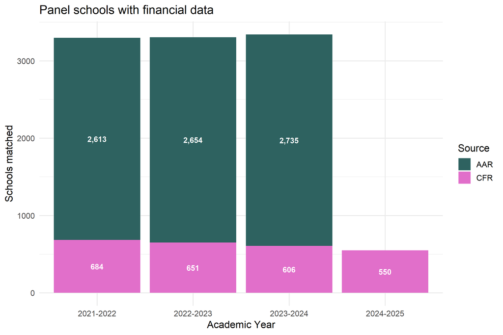

Figure 1: Panel match rate by year and financial data source

```r
panel %>%
  filter(!is.na(fin_total_income)) %>%
  count(academic_year, fin_source) %>%
  ggplot(aes(academic_year, n, fill = fin_source)) +
  geom_col(position = "stack") +
  scale_fill_manual(values = c(AAR = "#2e6260", CFR = "#e16fca"), name = "Source") +
  labs(x = "Academic Year", y = "Schools matched",
       title = "Panel schools with financial data") +
  geom_text(aes(label = comma(n)), position = position_stack(vjust = 0.5),
            size = 3.5, colour = "white", fontface = "bold")
```

# 5 Descriptive Statistics

## 5.1 Income and Expenditure (KS4 Panel Schools)

```r
panel_fin %>%
  summarise(
    across(
      c(fin_total_income, fin_total_expenditure, fin_in_year_balance,
        fin_grant_funding, fin_staff_costs, fin_teaching_staff,
        fin_premises_costs, fin_energy),
      list(
        Median = ~median(.x, na.rm = TRUE),
        Mean = ~mean(.x, na.rm = TRUE),
        SD = ~sd(.x, na.rm = TRUE),
        Min = ~min(.x, na.rm = TRUE),
        Max = ~max(.x, na.rm = TRUE)
      ),
      .names = "{.col}|{.fn}"
    )
  ) %>%
  pivot_longer(everything(), names_to = c("Variable", "Stat"), names_sep = "\\|") %>%
  pivot_wider(names_from = Stat, values_from = value) %>%
  mutate(
    Variable = str_remove(Variable, "^fin_"),
    across(Median:Max, ~comma(.x, accuracy = 1, prefix = "\u00A3"))
  ) %>%
  kable()
```

Table 5: Summary statistics for key financial variables (KS4 panel schools with financial data)

| Variable | Median | Mean | SD | Min | Max |
| --- | --- | --- | --- | --- | --- |
| total_income | £7,605,000 | £7,786,230 | £3,003,794 | -£22,964 | £26,602,000 |
| total_expenditure | £7,250,120 | £7,467,847 | £2,946,836 | £0 | £27,265,000 |
| in_year_balance | £226,000 | £318,383 | £640,361 | -£4,856,000 | £11,196,000 |
| grant_funding | £7,398,000 | £7,548,952 | £2,890,912 | -£23,286 | £26,269,000 |
| staff_costs | £5,481,000 | £5,617,791 | £2,227,195 | £0 | £21,081,000 |
| teaching_staff | £3,994,000 | £4,100,679 | £1,692,002 | £0 | £14,864,000 |
| premises_costs | £406,000 | £491,929 | £393,389 | -£864,000 | £11,574,000 |
| energy | £154,000 | £167,692 | £108,582 | -£301,000 | £1,030,755 |

## 5.2 Per-Pupil Metrics

```r
panel_fin %>%
  summarise(
    across(
      c(fin_total_income_pp, fin_total_expenditure_pp, fin_staff_costs_pp,
        fin_teaching_staff_pp, fin_grant_funding_pp),
      list(
        Median = ~median(.x, na.rm = TRUE),
        Mean = ~mean(.x, na.rm = TRUE),
        Q25 = ~quantile(.x, 0.25, na.rm = TRUE),
        Q75 = ~quantile(.x, 0.75, na.rm = TRUE)
      ),
      .names = "{.col}|{.fn}"
    )
  ) %>%
  pivot_longer(everything(), names_to = c("Variable", "Stat"), names_sep = "\\|") %>%
  pivot_wider(names_from = Stat, values_from = value) %>%
  mutate(
    Variable = str_remove(Variable, "^fin_") %>% str_replace_all("_", " "),
    across(Median:Q75, ~comma(.x, accuracy = 1, prefix = "\u00A3"))
  ) %>%
  kable()
```

Table 6: Per-pupil financial metrics (KS4 panel schools)

| Variable | Median | Mean | Q25 | Q75 |
| --- | --- | --- | --- | --- |
| total income pp | £7,206 | £7,390 | £6,591 | £7,988 |
| total expenditure pp | £6,910 | £7,086 | £6,256 | £7,700 |
| staff costs pp | £5,195 | £5,308 | £4,756 | £5,747 |
| teaching staff pp | £3,793 | £3,853 | £3,471 | £4,176 |
| grant funding pp | £6,987 | £7,164 | £6,387 | £7,752 |

# 6 Distributions

## 6.1 Income Per Pupil by Year

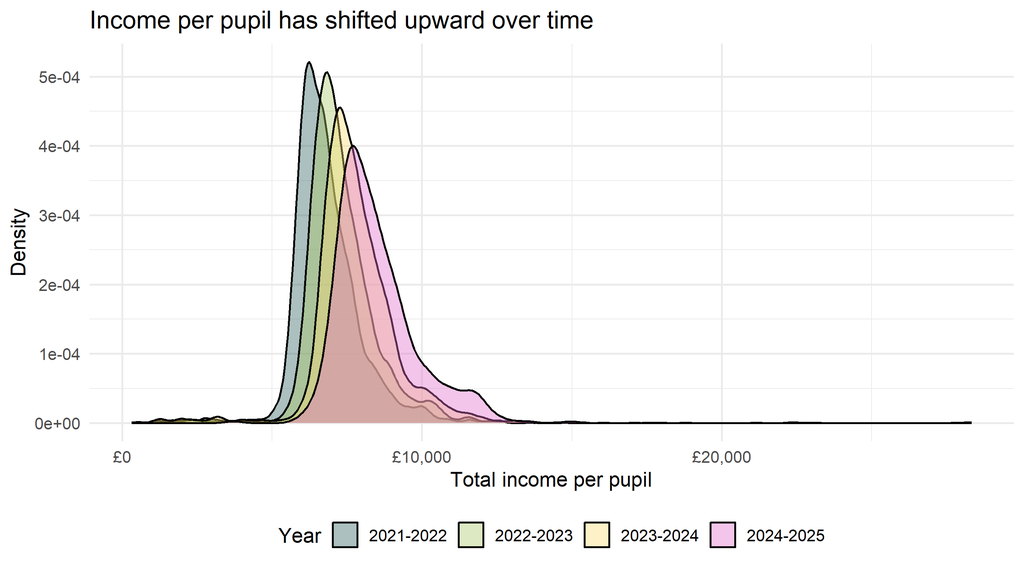

Figure 2: Distribution of total income per pupil by academic year

```r
panel_fin %>%
  filter(fin_total_income_pp > 0, fin_total_income_pp < 30000) %>%
  ggplot(aes(fin_total_income_pp, fill = academic_year)) +
  geom_density(alpha = 0.4) +
  scale_x_continuous(labels = label_comma(prefix = "\u00A3")) +
  scale_fill_manual(values = c("#2e6260", "#abc766", "#f9dd73", "#e16fca", "#4e3c56", "#49a0c4", "#ff7f89"), name = "Year") +
  labs(x = "Total income per pupil", y = "Density",
       title = "Income per pupil has shifted upward over time") +
  theme(legend.position = "bottom")
```

## 6.2 Expenditure Per Pupil by Source

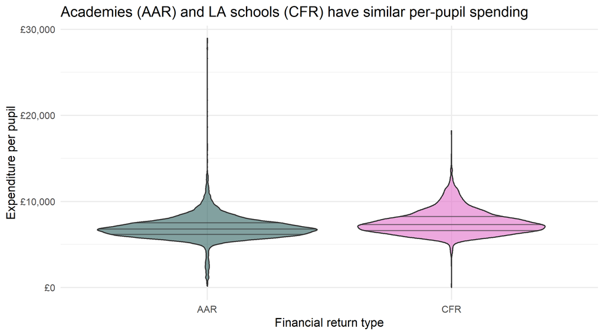

Figure 3: Expenditure per pupil by data source (CFR vs AAR)

```r
panel_fin %>%
  filter(fin_total_expenditure_pp > 0, fin_total_expenditure_pp < 30000) %>%
  ggplot(aes(fin_source, fin_total_expenditure_pp, fill = fin_source)) +
  geom_violin(alpha = 0.6, draw_quantiles = c(0.25, 0.5, 0.75)) +
  scale_y_continuous(labels = label_comma(prefix = "\u00A3")) +
  scale_fill_manual(values = c(AAR = "#2e6260", CFR = "#e16fca"), guide = "none") +
  labs(x = "Financial return type", y = "Expenditure per pupil",
       title = "Academies (AAR) and LA schools (CFR) have similar per-pupil spending")
```

## 6.3 Spending Composition

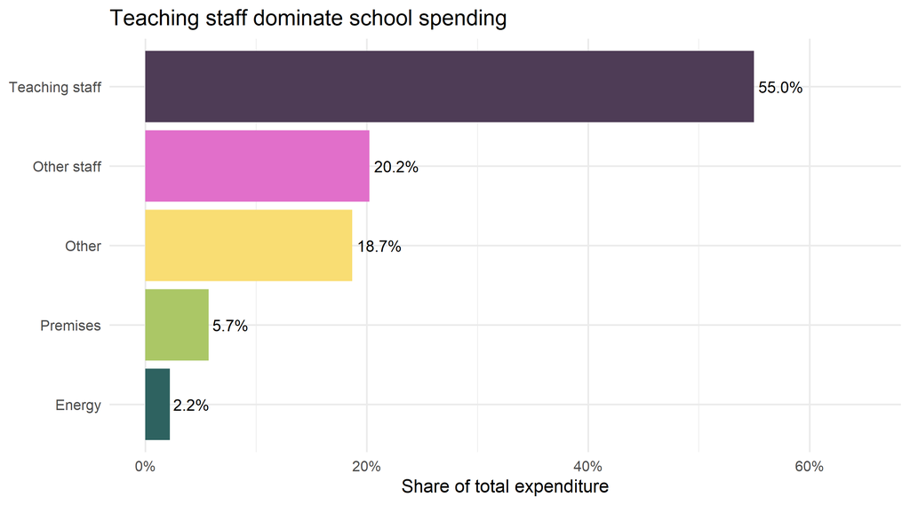

Figure 4: Median expenditure composition for KS4 schools

```r
panel_fin %>%
  filter(!is.na(fin_total_expenditure), fin_total_expenditure > 0) %>%
  summarise(
    `Teaching staff` = median(fin_teaching_staff / fin_total_expenditure, na.rm = TRUE),
    `Other staff` = median((fin_staff_costs - fin_teaching_staff) / fin_total_expenditure, na.rm = TRUE),
    `Premises` = median(fin_premises_costs / fin_total_expenditure, na.rm = TRUE),
    `Energy` = median(fin_energy / fin_total_expenditure, na.rm = TRUE),
    `Other` = 1 - median(fin_staff_costs / fin_total_expenditure, na.rm = TRUE) -
      median(fin_premises_costs / fin_total_expenditure, na.rm = TRUE)
  ) %>%
  pivot_longer(everything(), names_to = "Category", values_to = "Share") %>%
  mutate(
    Category = fct_reorder(Category, Share),
    label = percent(Share, accuracy = 0.1)
  ) %>%
  ggplot(aes(Share, Category, fill = Category)) +
  geom_col(show.legend = FALSE) +
  geom_text(aes(label = label), hjust = -0.1, size = 4) +
  scale_x_continuous(labels = percent, limits = c(0, 0.65)) +
  scale_fill_manual(values = c("#2e6260", "#abc766", "#f9dd73", "#e16fca", "#4e3c56", "#49a0c4", "#ff7f89")) +
  labs(x = "Share of total expenditure", y = NULL,
       title = "Teaching staff dominate school spending")
```

# 7 Trends Over Time

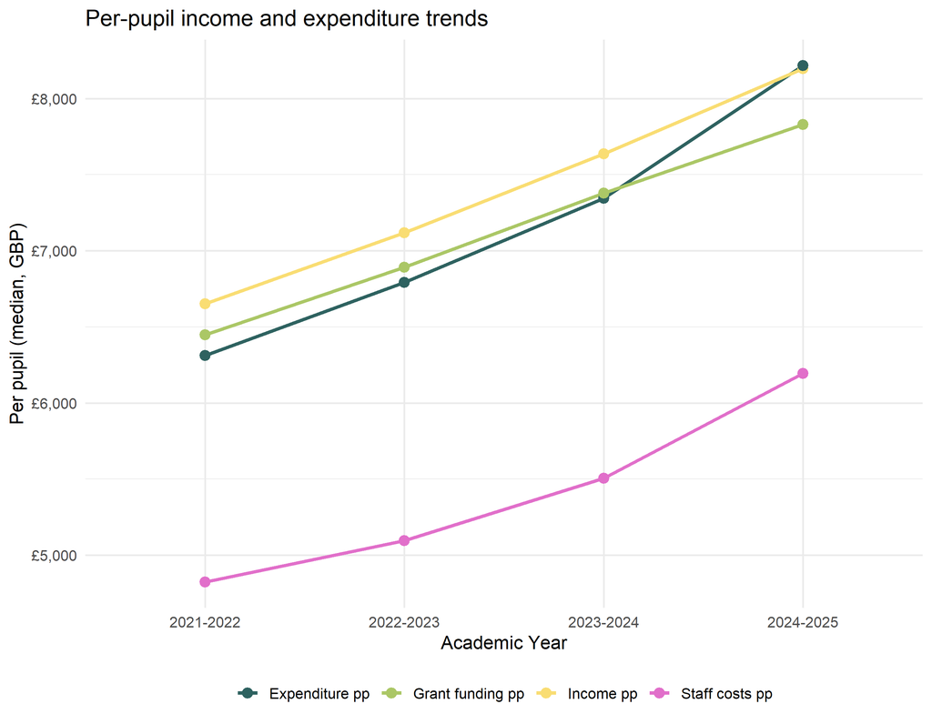

Figure 5: Median per-pupil metrics over time

```r
trends <- panel_fin %>%
  group_by(academic_year) %>%
  summarise(
    `Income pp` = median(fin_total_income_pp, na.rm = TRUE),
    `Expenditure pp` = median(fin_total_expenditure_pp, na.rm = TRUE),
    `Staff costs pp` = median(fin_staff_costs_pp, na.rm = TRUE),
    `Grant funding pp` = median(fin_grant_funding_pp, na.rm = TRUE),
    .groups = "drop"
  ) %>%
  pivot_longer(-academic_year, names_to = "Metric", values_to = "Value")

ggplot(trends, aes(academic_year, Value, colour = Metric, group = Metric)) +
  geom_line(linewidth = 1.2) +
  geom_point(size = 3) +
  scale_y_continuous(labels = label_comma(prefix = "\u00A3")) +
  scale_colour_manual(values = c("#2e6260", "#abc766", "#f9dd73", "#e16fca", "#4e3c56", "#49a0c4", "#ff7f89")) +
  labs(x = "Academic Year", y = "Per pupil (median, GBP)",
       title = "Per-pupil income and expenditure trends",
       colour = NULL) +
  theme(legend.position = "bottom")
```

# 8 Financial Health Indicators

## 8.1 In-Year Balance Distribution

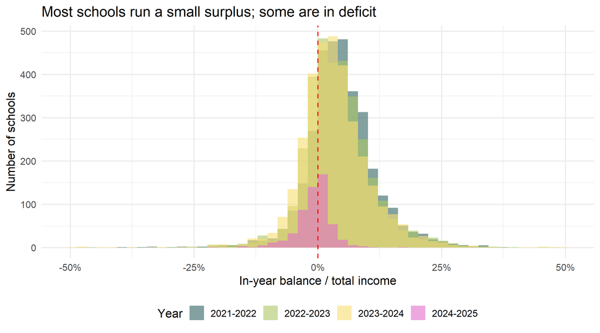

Figure 6: Distribution of in-year balance as % of income

```r
panel_fin %>%
  filter(!is.na(fin_balance_income_ratio),
         abs(fin_balance_income_ratio) < 0.5) %>%
  ggplot(aes(fin_balance_income_ratio, fill = academic_year)) +
  geom_histogram(bins = 50, alpha = 0.6, position = "identity") +
  geom_vline(xintercept = 0, linetype = "dashed", colour = "red") +
  scale_x_continuous(labels = percent) +
  scale_fill_manual(values = c("#2e6260", "#abc766", "#f9dd73", "#e16fca", "#4e3c56", "#49a0c4", "#ff7f89"), name = "Year") +
  labs(x = "In-year balance / total income",
       y = "Number of schools",
       title = "Most schools run a small surplus; some are in deficit") +
  theme(legend.position = "bottom")
```

## 8.2 Schools in Deficit

```r
panel_fin %>%
  filter(!is.na(fin_in_year_balance)) %>%
  group_by(`Academic Year` = academic_year) %>%
  summarise(
    Schools = n(),
    `In Deficit` = sum(fin_in_year_balance < 0),
    `% in Deficit` = percent(mean(fin_in_year_balance < 0), accuracy = 0.1),
    `Median Deficit (GBP)` = comma(
      median(fin_in_year_balance[fin_in_year_balance < 0]),
      prefix = "\u00A3"
    ),
    .groups = "drop"
  ) %>%
  kable()
```

Table 7: Proportion of KS4 schools running a deficit (negative in-year balance)

| Academic Year | Schools | In Deficit | % in Deficit | Median Deficit (GBP) |
| --- | --- | --- | --- | --- |
| 2021-2022 | 3297 | 629 | 19.1% | -£155,873 |
| 2022-2023 | 3305 | 853 | 25.8% | -£152,000 |
| 2023-2024 | 3341 | 967 | 28.9% | -£194,000 |
| 2024-2025 | 550 | 298 | 54.2% | -£208,461 |